```python
%load_ext texbook_theme
```

```python
%texify
```

# Jupyter $\TeX$book Theme

This notebook exhibits the main features of the $\TeX$book theme for Jupyter notebooks. We start with a bit of a spoiler *quick overlook* here, and then we go much further in all the nuts and bolts.

### $\TeX\text{book}$ shall be *thy name*

When I designed this theme, I was aiming towards a notebook experience which had the elegance and sobriety of a $\LaTeX$-generated article, perfectly combined with the flexibility and interactivity of Jupyter. And so $\TeX\text{book}$ seemed to be the most obvious solution for a name, a unique portmanteau$^1$, blending together the words $\LaTeX$ and *note**book***. Incidentally, this is also the name of the [Donald E. Knuth](https://en.wikipedia.org/wiki/Donald_Knuth)'s [book](http://www.ctex.org/documents/shredder/src/texbook.pdf) on $\TeX$.

That was the **omen**. The sign that this name was indeed perfect...

> Right!, One!... Two!... Five! $^2$

The $\TeX\text{book}$ Jupyter notebook theme wishes to pay a tribute of gratitude (in the name, and in the content) to two of the technologies I do use the most as researcher and data scientist.

*$1$:* `port·man·teau | \ pȯrt-ˈman-(ˌ)tō` *$2$:*[The Holy Hand Granade](https://www.youtube.com/watch?v=xOrgLj9lOwk) - Monthy Python and the Holy Grail

#### $\TeX$book Theme in a Nutshell

- *Computer Modern* fonts for Markdown typesetting;
- `Fira Code` font for the Code editor;
- `Hack` font for Markdown editor (slightly better for text writing, imho);
- `md` and `code` colour highlight theme based on Material Design colour scheme.
  - plus **easy-to-plug-in** new/extra CSS custom editor themes, e.g. `GitHub-Light` (see examples)

    ```
    #include <stdio.h>
    int main() {
      int i, n, t1 = 0, t2 = 1, nextTerm;
      printf("Enter the number of terms: ");
      scanf("%d", &n);
      printf("Fibonacci Series: ");

      for (i = 1; i <= n; ++i) {
          printf("%d, ", t1);
          nextTerm = t1 + t2;
          t1 = t2;
          t2 = nextTerm;
      }

      return 0;
    }
    ```

- Extra CSS Classes for Markdown and Code (output) formatting

#### $\TeX$book theme in summary

- Colour Palette
  - Text Colour
- Fonts and Typeface
- Markdown
  - Headers
  - Emphasis
  - Lists
  - Images
  - Code and Syntaxt Highlithing
  - Tables
  - Blockquotes
  - Math
  - Extras
    - Footnotes
    - Drop Cap
    - Image Widths
- Code
  - Code Editor
  - Errors
  - Dataframe
- Miscellaneous
- Credits

## Colour Palette

```python
import numpy as np
import cv2
import matplotlib as mpl
import matplotlib.pyplot as plt

# Matplotlib Configuration Params
%matplotlib inline
%config InlineBackend.figure_format = 'retina'

mpl.rcParams['figure.figsize'] = (18,1)
```

```python
# Color Palette
colours = {"red": "#d43133",
           "magenta" : "#D14187",
           "torquoise" : "#009489",
           "azure": "#00afde",
           "blue": "#2875d9",
           "light-grey": "#828282",
           "dark-grey": "#383838"
          }
```

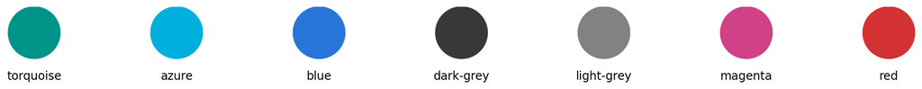

```python
def hex2rgb(h: str):
    """helper to convert hex colours into RGB tuple"""
    h = h.lstrip('#')
    return tuple(int(h[i:i+2], 16) for i in (0, 2, 4))

# Create a black image
image = np.full((1024,1024,3), 255, np.uint8)

def show_palette(colours):
    n_cols = len(colours)
    fig = plt.figure()
    for i, (colour, hexcode) in enumerate(sorted(colours.items(), key=lambda e: hex2rgb(e[1]))):
        axis = fig.add_subplot(1,n_cols,i+1)
        rgb = hex2rgb(hexcode)
        cv2.circle(image, (512, 512), 512, (rgb[0], rgb[1], rgb[2]), -1)
        plt.title(colour, y=-0.5)
        plt.axis('off')
        plt.imshow(image);

show_palette(colours)
```

#### Text Colours

$\rightarrow$ **Torquoise**; **Azure**; **Blue**; **Dark Grey**; **Light Grey**; **Magenta**; **Red** $\leftarrow$

$\uparrow$ top

## Fonts and Typeface

The $\TeX$book theme typeface design is based on all fonts **open source** and freely available on public **font repositories** (e.g., [Google Fonts](https://fonts.google.com/), [DaFont](https://www.dafont.com/), or [FontSquirrel](https://www.fontsquirrel.com/)). All the main fonts used are released under the [OFL](https://opensource.org/licenses/OFL-1.1) (**O**pen **F**ont **L**icense), and alike. Original reference and download links are provided below.

**Note**: All used fonts and typefaces are included in the repository (see the `fonts` folder), and configured in the `fonts.css` stylesheet according to multiple `font-style`, and `font-weight` as needed.

###### $TeX$Book typeface

The main goal of the $\TeX$book theme is to allow Jupyter notebooks to render like a $\LaTeX$-generated article. Therefore, the (**Markdown**) text rendering adopts the good ol' [*Computer Modern*](https://en.wikipedia.org/wiki/Computer_Modern) font family for both serif and `monospace` text (i.e. `CMUSerif` and `CMUTypewriter` fonts, respectively).

*[1]:*The support for ligatures in the Markdown editor would be useless anyway, being then rendered in Computer Modern font.

###### Notebook UI

The font used for everything else in the Notebook UI and look-and-feel (e.g. `header`, `navbar`, *jupyter-srever home page* (notebook list) uses the [`Roboto Slab`](https://fonts.google.com/specimen/Roboto+Slab) font.

###### Font References and Links

| Font | Format | Reference | License | Download |
| --- | --- | --- | --- | --- |
| `Computer Modern` | OpenType (`otf`) | [tug.org](https://tug.org/FontCatalogue/computermodern/) | [SIL OFL](https://www.fontsquirrel.com/license/computer-modern) | [[$\Downarrow$]](https://www.checkmyworking.com/cm-web-fonts/Computer%20Modern.zip) |
| `Hack` | TrueType (`ttf`) | [Github](https://github.com/source-foundry/Hack) | [MIT](https://github.com/source-foundry/Hack/blob/master/LICENSE.md) | [[$\Downarrow$]](https://github.com/source-foundry/Hack/releases) |
| `Fira Code` | OpenType (`otf`) | [Github](https://github.com/tonsky/FiraCode) | [SIL OFT](https://github.com/tonsky/FiraCode/blob/master/LICENSE) | [[$\Downarrow$]](https://github.com/tonsky/FiraCode/releases/) |
| `Roboto Slab` | OpenType (`otf`) | [Google Fonts](https://fonts.google.com/specimen/Roboto+Slab) | [Apache License, v2.0](https://fonts.google.com/specimen/Roboto+Slab#license) | [[$\Downarrow$]](https://fonts.google.com/download?family=Roboto%20Slab) |

$\uparrow$ top

## Markdown

(Adapted from [Markdown Cheatsheet](https://github.com/adam-p/markdown-here/wiki/Markdown-Cheatsheet)) License: [CC-BY](https://creativecommons.org/licenses/by/3.0/)

# Part (`h1`)

## Chapter (`h2`)

### Section (`h3`)

#### Subsection (`h4`)

##### Subsubsection (`h5`)

###### Paragraph (`h6`)

$\uparrow$ top

#### Text and Emphasis

Emphasis, aka italics, with *asterisks* or *underscores*.

Strong emphasis, aka bold, with **asterisks** or **underscores**.

Combined emphasis with **asterisks and *underscores***, also for **`bold`** *`italic`* `mono`

```
Mono blocks are supported too.
```

Strikethrough uses two tildes, colored in **red**: Scratch this.

$\uparrow$ top

#### Lists

**Unordered list can use asterisks**

- First item
- Second item
  - Third item
    - Another level

**Ordered Lists** (and combinations)

1. First ordered list item
2. Another item with `mono`
   - Unordered sub-list.
3. Actual numbers don't matter, just that it's a number
   1. Ordered sub-list
4. And another item.

$\uparrow$ top

#### Images

- Inline-style:
- Reference-style:

$\uparrow$ top

#### Code and Syntax Highlighting

Syntax highlighting is supported: it uses the `CMUTypewriter` as for the font face, and the color scheme is the very same used for **code** cells (more on this later).

```
// Javascript highlighting
$(document).ready(function(){
    $(a).click(function(e){
        e.preventDefault();
        $(this).slideUp(300)
    });
});
```

```
# Python highlighting
import antigravity
from __future__ import barry_as_FLUFL  # PEP401
```

```
echo "Shell syntaxt highlighting"
```

$\uparrow$ top

#### Tables

Tables aren't part of the core Markdown spec, but they are part of GFM and *Markdown Here* supports them. They are an easy way of adding tables to your email -- a task that would otherwise require copy-pasting from another application.

Colons can be used to align columns.

| Tables | Are | Cool |
| --- | --- | --- |
| col 3 is | right-aligned | \$1600 |
| col 2 is | centered | \$12 |
| zebra stripes | are neat | \$1 |

There must be at least 3 dashes separating each header cell. The outer pipes (|) are optional, and you don't need to make the raw Markdown line up prettily. You can also use inline Markdown.

| Markdown | Less | Pretty |
| --- | --- | --- |
| *Still* | `renders` | **nicely** |
| 1 | 2 | 3 |

$\uparrow$ top

#### Blockquotes

> Blockquotes are very handy in email to emulate reply text. This line is part of the same quote.

Quote break.

> This is a very long line that will still be quoted properly when it wraps. Oh boy let's keep writing to make sure this is long enough to actually wrap for everyone. Oh, you can *put* **Markdown** into a blockquote.

$\uparrow$ top

#### Math

Math and $LaTeX$ text style integration is supported (via MathJax) both in **inline** and **block** modes.

**Inline math**: $ X^2 + 1 = 1 $ works fine.

**Math block**:

$$ X^2 + 1 = 1 $$

Some more Math examples taken from [Latex/Advanced Mathematics](https://en.wikibooks.org/wiki/LaTeX/Advanced_Mathematics):

$$ \begin{equation} f(x)=(x+a)(x+b) \end{equation} $$$$ \begin{equation} L' = {L}{\sqrt{1-\frac{v^2}{c^2}}} \end{equation} $$

**Maxwell's equations:** $$ \begin{equation} \left.\begin{aligned} B'&=-\partial \times E,\\ E'&=\partial \times B - 4\pi j, \end{aligned} \right\} \qquad \text{Maxwell's equations} \end{equation} $$

**Factorials and Binomials:** $$ \frac{n!}{k!(n-k)!} = \binom{n}{k} $$

*fraction within a fraction* $$ \frac{\frac{1}{x}+\frac{1}{y}}{y-z} $$

**Limits**: $$ \begin{equation} \lim_{a\to \infty} \tfrac{1}{a} \end{equation} $$

**Math formulas with comments**:

$$ [ y = a + f(\underbrace{b x}_{ \ge 0 \text{ by assumption}}) = a + f(\underbrace{b x}_{ \ge 0 \text{ by assumption}}) ] $$

**`gather`**: Consecutive equations without alignment $$ \begin{gather*} a_0=\frac{1}{\pi}\int\limits_{-\pi}^{\pi}f(x)\,\mathrm{d}x\\[6pt] \begin{split} a_n=\frac{1}{\pi}\int\limits_{-\pi}^{\pi}f(x)\cos nx\,\mathrm{d}x=\\ =\frac{1}{\pi}\int\limits_{-\pi}^{\pi}x^2\cos nx\,\mathrm{d}x \end{split}\\[6pt] \begin{split} b_n=\frac{1}{\pi}\int\limits_{-\pi}^{\pi}f(x)\sin nx\,\mathrm{d}x=\\ =\frac{1}{\pi}\int\limits_{-\pi}^{\pi}x^2\sin nx\,\mathrm{d}x \end{split}\\[6pt] \end{gather*} $$

**`alignat`**: Allows control of the horizontal space between equations. $$ \begin{alignat}{2} \sigma_1 &= x + y &\quad \sigma_2 &= \frac{x}{y} \\ \sigma_1' &= \frac{\partial x + y}{\partial x} & \sigma_2' &= \frac{\partial \frac{x}{y}}{\partial x} \end{alignat} $$

$\uparrow$ top

#### Extras

In addition to standard Markdown integration, the $\TeX$book theme provides some extra CSS classes to allow for extra formattings and flexibility in typesetting. These include:

1. Footnotes
2. Drop Cap
3. Image Width

$\uparrow$ top

##### Footnotes

To define a new footnote which complies to the CSS directives specified in the $\TeX$book theme, the following **HTML** code should be used:

```
<span id="fn1-ex"><i>[1]:</i> This is an example of a footnote</span>
```

Footnotes could be identified by an `id` starting with the `fn` prefix (the CSS matching rule is `[id^='fn']`). The definition of footnotes via (**unique**) `id`s will also make footnotes to be automatically retrieved via **anchor** links in *footnote reference*.

It is also possible to emphasize the *footnote reference* using the `<i>` tag.

The resulting style of a footnote$^1$ is as follows:

*[1]:* This is an example of a footnote

If we want to stack multiple$^{1st}$ footnotes in the same Markdown cell$^{2nd}$, the CSS will comply:

*[1]:* This is an example of a footnote *[2]:* This is the **second** example of a footnote

*Last but not least*, if we want or need to identify a footnote with a specific `id` that will not comply with the `fn` prefix requirement, the `.fn` class can be used instead$^{CSS}$:

```
<span id="css" class="fn"><i>[1]:</i> This is footnote of class `.fn` and any `id`</span>
```

*[`.fn` CSS Class]:* This is footnote of class `.fn` and any `id`

$\uparrow$ top

##### Drop Cap

A special class to display a [**drop cap**](https://en.wiktionary.org/wiki/drop_cap) could not be missing in the $\TeX$book theme.

It is just required to use the `drop` `CSS` class.

$\uparrow$ top

##### Image Width

As default, the `max-width` of images (and SVG) is automatically capped at the `70%` to allow for a proper rendering of large images, avoiding any potential overflow. However, there may be cases in which it could be required to control the `max-width` parameter in order to enlarge or shrink an image. To do so, some special `CSS` classes have been defined to control the value of `max-width` attribute.

Here are the available `CSS` **classes** and corresponding display of the same image at different size.

**Default**:

[figure not shown]

- `maxw10` $\Rightarrow$ `max-width: 10%`

[figure not shown]

- `maxw15` $\Rightarrow$ `max-width: 15%`

[figure not shown]

- `maxw20` $\Rightarrow$ `max-width: 20%`

[figure not shown]

- `maxw25` $\Rightarrow$ `max-width: 25%`

[figure not shown]

- `maxw30` $\Rightarrow$ `max-width: 30%`

[figure not shown]

- `maxw40` $\Rightarrow$ `max-width: 40%`

[figure not shown]

- `maxw50` $\Rightarrow$ `max-width: 50%`

[figure not shown]

- `maxw80` $\Rightarrow$ `max-width: 80%`

[figure not shown]

- `maxw85` $\Rightarrow$ `max-width: 85%`

[figure not shown]

- `maxw90` $\Rightarrow$ `max-width: 90%`

[figure not shown]

- `maxw100` $\Rightarrow$ `max-width: 100%`

[figure not shown]

$\uparrow$ top

## Code Sample

Here is how Python code looks like in $\TeX$book theme.

The following code excerpt has been taken from the **PyTorch** code base ([source](https://github.com/pytorch/pytorch/blob/master/torch/utils/data/dataset.py#L4))

```python
class Dataset(object):
    r"""An abstract class representing a :class:`Dataset`.
    All datasets that represent a map from keys to data samples should subclass
    it. All subclasses should overwrite :meth:`__getitem__`, supporting fetching a
    data sample for a given key. Subclasses could also optionally overwrite
    :meth:`__len__`, which is expected to return the size of the dataset by many
    :class:`~torch.utils.data.Sampler` implementations and the default options
    of :class:`~torch.utils.data.DataLoader`.
    .. note::
      :class:`~torch.utils.data.DataLoader` by default constructs a index
      sampler that yields integral indices.  To make it work with a map-style
      dataset with non-integral indices/keys, a custom sampler must be provided.
    """

    def __getitem__(self, index):
        raise NotImplementedError

    def __add__(self, other):
        return ConcatDataset([self, other])

    # No `def __len__(self)` default?
    # See NOTE [ Lack of Default `__len__` in Python Abstract Base Classes ]
    # in pytorch/torch/utils/data/sampler.py
```

$\uparrow$ top

### Code Editor

The CSS style for code and markdown editor integrated in the $\TeX$book theme adopts a strategy that aims at *flexibility* and *extensibility*.

The main style file for code editors is `editors.css`. This file *imports* each theme for both code and markdown editors. The themes for the two editors are defined in two different files, to allow for maxmimum flexibility in the choice of the colours schemes to adopt.

In each theme file, the base **colour** palette is defined, along with the mapping of each of these colours to specific (editor) variables. These variables are then used to define the CSS style rules.

In this way, it is very easy to change or try multiple themes, or even defining custom new ones.

The default colour scheme used for code and markdown editor is based on the **Material Design Light** [Theme](https://github.com/JonaDuran/Material-Light-Theme/). In addition, other editor themes are bundled in the $\TeX$book Jupyter theme, e.g. `GitHub Light` for code, `Typora` theme for markdown.

The base colour palettes for each of those themes are showed below.

#### Material Design Light Theme (Default)

*(available for **code** \& **markdown** editor)*

The default colour palette used for both Code and Markdown editors is inspired by the Material Design [Light Theme](https://github.com/JonaDuran/Material-Light-Theme/).

The colour palette is declined on `12` colours, reported below:

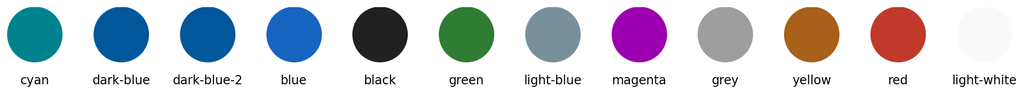

```python
material_code_colours = {
    "light-white": "#FAFAFA",
    "black": "#212121",
    "dark-blue" : "#01579B11",
    "dark-blue-2": "#01579B22",
    "blue": "#1565C0",
    "green": "#2E7D32",
    "yellow": "#A8601A",
    "cyan": "#00838f",
    "magenta": "#9C00B0",
    "red": "#C0392B",
    "grey": "#9E9E9E",
    "light-blue": "#78909c"
}

show_palette(material_code_colours)
```

The **Markdown** editor uses only a subset of those colours. In particular:

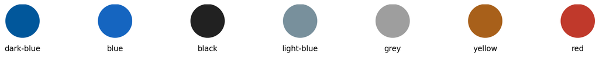

```python
material_md_colours = {
    "black": "#212121",
    "dark-blue" : "#01579B11",
    "blue": "#1565C0",
    "yellow": "#A8601A",
    "red": "#C0392B",
    "grey": "#9E9E9E",
    "light-blue": "#78909c"
}

show_palette(material_md_colours)
```

#### GitHub Light Theme

*(only available for the **code** editor)*

The **GitHub Light** theme builds on the default GitHub light theme.

**Reference**: [Github Syntax Highlighting](https://github.com/primer/github-syntax-light)

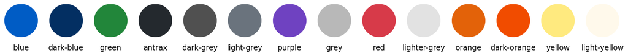

```python
github_code_colours = {
    "dark-grey": "#505050",
    "grey": "#b8b8b8",
    "light-grey": "#6a737d",
    "lighter-grey": "#e2e2e2",
    "antrax": "#24292e",
    "red": "#d73a49",
    "orange": "#e36209",
    "dark-orange": "#f14c00",
    "purple": "#6f42c1",
    "light-yellow": "#fff9eb",
    "yellow": "#ffea7f",
    "blue": "#005cc5",
    "dark-blue": "#032f62",
    "green": "#22863a"
}

show_palette(github_code_colours)
```

#### Crisp Light Theme

*(only available for the **code** editor)*

The colour palette of the **Crisp Light** editor theme is inspired by the Crisp light theme included in the **Rainglow** collection of VSCode Themes

**Reference**: https://github.com/rainglow/vscode/

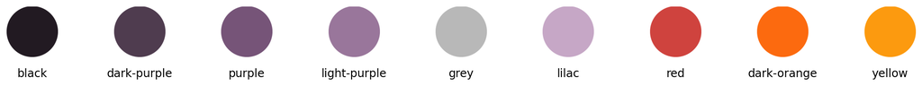

```python
crisp_code_colours = {
    "lilac": "#c6a7c6",
    "black": "#221a22",
    "grey": "#b8b8b8",
    "yellow": "#fc9a0f",
    "dark-orange": "#fc6a0f",
    "purple": "#765478",
    "dark-purple": "#4f3c4f",
    "light-purple": "#99769b",
    "red": "#cf433e"
}

show_palette(crisp_code_colours)
```

#### Typora Theme

*(only available for the **markdown** editor)*

This theme is inspired by the default (markdown) source code visualiser available built-in in [Typora](https://typora.io/)$^{md}$

*[md]*: Typora is definitely my default editor for Markdown! Highly recommended $\rightarrow$ [typora.io](http://typora.io)

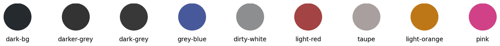

```python
typora_md_colours = {
    "pink": "#d14187",
    "dark-grey": "#383838",
    "darker-grey": "#333333",
    "taupe": "#a99f9f",
    "light-orange": "#be7716",
    "light-red": "#a34343",
    "grey-blue": "#48599b",
    "dark-bg": "#252a2f",
    "dirty-white": "#8d8e8f"
}

show_palette(typora_md_colours)
```

#### Errors and Exceptions

```python
from wherever import non_existing_module
```

```
---------------------------------------------------------------------------
ModuleNotFoundError                       Traceback (most recent call last)
<ipython-input-12-40a1e5a99230> in <module>
----> 1 from wherever import non_existing_module

ModuleNotFoundError: No module named 'wherever'
```

```python
from scipy import linalg
linalg.det(np.ones((3, 4)))
```

```
---------------------------------------------------------------------------
ValueError                                Traceback (most recent call last)
<ipython-input-13-5162a496210c> in <module>
      1 from scipy import linalg
----> 2 linalg.det(np.ones((3, 4)))

~/opt/anaconda3/envs/texbook-theme/lib/python3.8/site-packages/scipy/linalg/basic.py in det(a, overwrite_a, check_finite)
   1032     a1 = _asarray_validated(a, check_finite=check_finite)
   1033     if len(a1.shape) != 2 or a1.shape[0] != a1.shape[1]:
-> 1034         raise ValueError('expected square matrix')
   1035     overwrite_a = overwrite_a or _datacopied(a1, a)
   1036     fdet, = get_flinalg_funcs(('det',), (a1,))

ValueError: expected square matrix
```

#### Dataframe

The look and feel of dataframes (tables) is slightly changed.

I've chosen a post-it note color for the table background so that dataframe output standsout, especially when scrolling through a long notebook.

```python
from sklearn.datasets import load_iris
import pandas as pd


iris = load_iris()
iris_df = pd.DataFrame(data= np.c_[iris['data'], iris['target']],
                     columns= iris['feature_names'] + ['target'])
iris_df.head()
```

|  | sepal length (cm) | sepal width (cm) | petal length (cm) | petal width (cm) | target |
| --- | --- | --- | --- | --- | --- |
| 0 | 5.1 | 3.5 | 1.4 | 0.2 | 0.0 |
| 1 | 4.9 | 3.0 | 1.4 | 0.2 | 0.0 |
| 2 | 4.7 | 3.2 | 1.3 | 0.2 | 0.0 |
| 3 | 4.6 | 3.1 | 1.5 | 0.2 | 0.0 |
| 4 | 5.0 | 3.6 | 1.4 | 0.2 | 0.0 |

## Miscellaneous

- notebook cell style
  - codecell overlay
- fixed bar (and custom JS)
- Changed colours?

$\uparrow$ top

## Credits

$\uparrow$ top